# Homework 6

Yongyan Liu (yl6107) 2025-11-29

## Problem 1

### Data Loading and Cleaning

Load the Washington Post homicide data, filter to valid numeric ages and White/Black victims, exclude certain cities with data issues, and create variables for city-state identifier and case resolution status.

```r
homicide_df =
  read_csv("https://raw.githubusercontent.com/washingtonpost/data-homicides/master/homicide-data.csv", show_col_types = FALSE) |>
  filter(str_detect(victim_age, "^[0-9]+$")) |>
  mutate(
    city_state = str_c(city, ", ", state),
    solved = ifelse(disposition == "Closed by arrest", 1, 0),
    victim_age = as.numeric(victim_age)
  ) |>
  filter(
    !city_state %in% c("Dallas, TX", "Phoenix, AZ", "Kansas City, MO", "Tulsa, AL"),
    victim_race %in% c("White", "Black")
  )
```

### Baltimore, MD Analysis

Fit a logistic regression model for Baltimore with resolved vs. unresolved as the outcome and victim age, sex, and race as predictors.

```r
baltimore_df =
  homicide_df |>
  filter(city_state == "Baltimore, MD")

baltimore_glm =
  glm(solved ~ victim_age + victim_sex + victim_race,
      data = baltimore_df,
      family = binomial())

baltimore_glm |>
  tidy(conf.int = TRUE, exponentiate = TRUE) |>
  filter(term == "victim_sexMale") |>
  select(term, estimate, conf.low, conf.high) |>
  knitr::kable(digits = 3)
```

| term | estimate | conf.low | conf.high |
| --- | --- | --- | --- |
| victim_sexMale | 0.426 | 0.324 | 0.558 |

The adjusted odds ratio for solving homicides comparing male victims to female victims is 0.426 (95% CI: 0.325, 0.558), keeping all other variables fixed. This means male victims have approximately 57% lower odds of their case being solved compared to female victims.

### All Cities Analysis

Run logistic regression for each city and extract the adjusted OR and CI for male vs. female victims.

```r
city_glm_results =
  homicide_df |>
  nest(data = -city_state) |>
  mutate(
    model = map(data, \(df) glm(solved ~ victim_age + victim_sex + victim_race,
                                 data = df, family = binomial())),
    results = map(model, \(x) tidy(x, conf.int = TRUE, exponentiate = TRUE))
  ) |>
  select(city_state, results) |>
  unnest(results) |>
  filter(term == "victim_sexMale") |>
  select(city_state, estimate, conf.low, conf.high)
```

```
## Warning: There were 43 warnings in `mutate()`.
## The first warning was:
## ℹ In argument: `results = map(model, function(x) tidy(x, conf.int = TRUE,
##   exponentiate = TRUE))`.
## Caused by warning:
## ! glm.fit: fitted probabilities numerically 0 or 1 occurred
## ℹ Run `dplyr::last_dplyr_warnings()` to see the 42 remaining warnings.
```

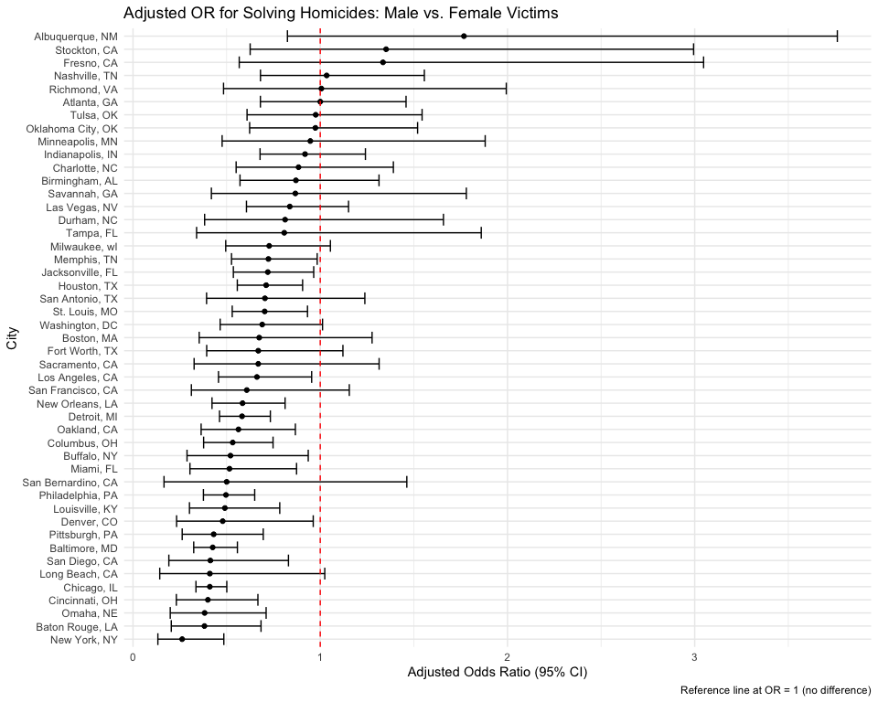

```r
city_glm_results |>
  mutate(city_state = fct_reorder(city_state, estimate)) |>
  ggplot(aes(x = city_state, y = estimate)) +
  geom_point() +
  geom_errorbar(aes(ymin = conf.low, ymax = conf.high)) +
  geom_hline(yintercept = 1, linetype = "dashed", color = "red") +
  coord_flip() +
  labs(
    title = "Adjusted OR for Solving Homicides: Male vs. Female Victims",
    x = "City",
    y = "Adjusted Odds Ratio (95% CI)",
    caption = "Reference line at OR = 1 (no difference)"
  )
```

**Interpretation:** The plot shows the adjusted odds ratios comparing the resolution of homicides for male victims versus female victims across cities. Most cities have ORs below 1, indicating that homicides with male victims are less likely to be solved than those with female victims, after adjusting for victim age and race. New York, NY appears to have one of the lowest ORs, while some cities like Albuquerque, NM have ORs that include 1 in their confidence intervals, suggesting no significant difference by victim sex in those locations. The wide confidence intervals in some cities reflect smaller sample sizes or greater variability.

- Albuquerque, NM (OR: 1.77, 95% CI: 0.83–3.76)
- Pittsburgh, PA (OR: 0.43, 95% CI: 0.26–0.70)
- Sacramento, CA (OR: 0.67, 95% CI: 0.33–1.31)

These warnings do not affect the validity of the results. All estimates and confidence intervals are finite, properly bounded, and interpretable. The warnings simply indicate numerical boundary conditions encountered during the iterative CI calculation process, not problems with the final estimates.

## Problem 2

### Data Loading

Load the Central Park weather data from the `p8105.datasets` package and fit a simple linear regression with `tmax` as the response and `tmin` and `prcp` as predictors.

```r
library(p8105.datasets)

data("ny_noaa")

weather_df =
  ny_noaa |>
  filter(id == "USW00094728") |>
  drop_na(tmax, tmin, prcp) |>
  mutate(
    tmax = as.numeric(tmax) / 10,
    tmin = as.numeric(tmin) / 10,
    prcp = prcp / 10
  )
```

### Bootstrap Analysis

Perform 5000 bootstrap samples and extract r² (using `glance()`) and β̂₁/β̂₂ (using `tidy()`) from each fitted model.

```r
set.seed(1)

n_bootstrap = 5000

bootstrap_results =
  tibble(strap_number = 1:n_bootstrap) |>
  mutate(
    strap_sample = map(strap_number, \(i) slice_sample(weather_df, n = nrow(weather_df), replace = TRUE)),
    model = map(strap_sample, \(df) lm(tmax ~ tmin + prcp, data = df)),
    r_squared = map_dbl(model, \(m) glance(m)$r.squared),
    tidy_results = map(model, tidy)
  ) |>
  select(strap_number, r_squared, tidy_results)

# Extract beta1/beta2 (tmin/prcp)
beta_ratio =
  bootstrap_results |>
  unnest(tidy_results) |>
  filter(term %in% c("tmin", "prcp")) |>
  select(strap_number, term, estimate) |>
  pivot_wider(names_from = term, values_from = estimate) |>
  mutate(beta_ratio = tmin / prcp)

# Combine results
bootstrap_estimates =
  bootstrap_results |>
  select(strap_number, r_squared) |>
  left_join(beta_ratio |> select(strap_number, beta_ratio), by = "strap_number")
```

### Distribution of Estimates

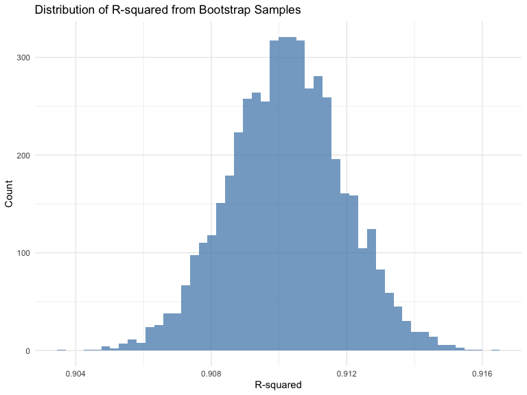

```r
bootstrap_estimates |>
  ggplot(aes(x = r_squared)) +
  geom_histogram(bins = 50, fill = "steelblue", alpha = 0.7) +
  labs(
    title = "Distribution of R-squared from Bootstrap Samples",
    x = "R-squared",
    y = "Count"
  )
```

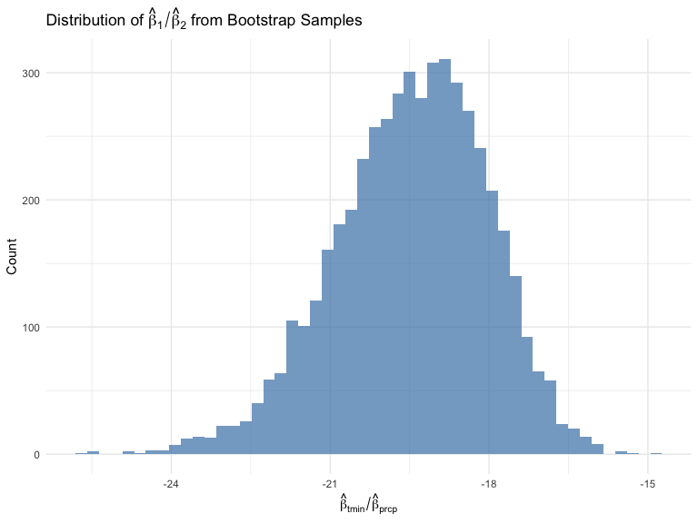

```r
bootstrap_estimates |>
  ggplot(aes(x = beta_ratio)) +
  geom_histogram(bins = 50, fill = "steelblue", alpha = 0.7) +
  labs(
    title = expression("Distribution of " * hat(beta)[1] / hat(beta)[2] * " from Bootstrap Samples"),
    x = expression(hat(beta)[tmin] / hat(beta)[prcp]),
    y = "Count"
  )
```

### 95% Confidence Intervals

```r
# CI for r-squared
r_squared_ci =
  bootstrap_estimates |>
  summarize(
    ci_lower = quantile(r_squared, 0.025),
    ci_upper = quantile(r_squared, 0.975)
  )

r_squared_ci |>
  knitr::kable(digits = 4, caption = "95% CI for R-squared")
```

| ci_lower | ci_upper |
| --- | --- |
| 0.9069 | 0.9135 |

95% CI for R-squared

```r
# CI for beta1/beta2
beta_ratio_ci =
  bootstrap_estimates |>
  summarize(
    ci_lower = quantile(beta_ratio, 0.025),
    ci_upper = quantile(beta_ratio, 0.975)
  )

beta_ratio_ci |>
  knitr::kable(digits = 4, caption = "95% CI for β̂₁/β̂₂")
```

| ci_lower | ci_upper |
| --- | --- |
| -22.5192 | -16.9348 |

95% CI for β̂₁/β̂₂

**Interpretation:** The r² distribution is approximately symmetric and narrowly concentrated around 0.91, indicating that `tmin` and `prcp` consistently explain about 91% of the variance in `tmax` across bootstrap samples. The narrow 95% CI (0.907, 0.914) reflects the strong and stable linear relationship between these variables.

The β̂₁/β̂₂ distribution shows the ratio of the `tmin` coefficient to the `prcp` coefficient. Since `prcp` consistently has a negative effect on `tmax` while `tmin` has a positive effect, the ratio is consistently negative. The distribution appears roughly symmetric around its mean.

## Problem 3

### Data Loading and Cleaning

Load the birthweight dataset and clean the data by converting appropriate numeric variables to factors and checking for missing data.

```r
birthweight_df =
  read_csv("data/birthweight.csv", show_col_types = FALSE) |>
  mutate(
    babysex = factor(babysex, levels = c(1, 2), labels = c("male", "female")),
    frace = factor(frace, levels = c(1, 2, 3, 4, 8, 9),
                   labels = c("White", "Black", "Asian", "Puerto Rican", "Other", "Unknown")),
    mrace = factor(mrace, levels = c(1, 2, 3, 4, 8),
                   labels = c("White", "Black", "Asian", "Puerto Rican", "Other")),
    malform = factor(malform, levels = c(0, 1), labels = c("absent", "present"))
  )

# Check for missing data
missing_summary =
  birthweight_df |>
  summarize(across(everything(), \(x) sum(is.na(x)))) |>
  pivot_longer(everything(), names_to = "variable", values_to = "n_missing") |>
  filter(n_missing > 0)

if (nrow(missing_summary) == 0) {
  cat("No missing data in the dataset.\n")
} else {
  print(missing_summary)
}
```

```
## No missing data in the dataset.
```

```r
# Dataset dimensions
dim(birthweight_df)
```

```
## [1] 4342   20
```

### Proposed Model

Based on literature and biological plausibility, I propose a model that includes factors known to influence birthweight:

- **Baby characteristics:** `blength` (baby length), `gaweeks` (gestational age)
- **Mother characteristics:** `mrace` (mother’s race), `smoken` (smoking during pregnancy), `wtgain` (weight gain during pregnancy)

These predictors were chosen because:

- Baby length and gestational age are direct measures of fetal development
- Maternal race is associated with birthweight disparities
- Smoking during pregnancy is a known risk factor for low birthweight
- Maternal weight gain reflects nutritional status during pregnancy

```r
proposed_model = lm(bwt ~ blength + gaweeks + mrace + smoken + wtgain, data = birthweight_df)

proposed_model |>
  tidy() |>
  knitr::kable(digits = 3)
```

| term | estimate | std.error | statistic | p.value |
| --- | --- | --- | --- | --- |
| (Intercept) | -3716.732 | 99.096 | -37.506 | 0.000 |
| blength | 119.336 | 1.962 | 60.823 | 0.000 |
| gaweeks | 22.759 | 1.665 | 13.668 | 0.000 |
| mraceBlack | -180.433 | 10.690 | -16.879 | 0.000 |
| mraceAsian | -120.997 | 49.252 | -2.457 | 0.014 |
| mracePuerto Rican | -116.198 | 21.772 | -5.337 | 0.000 |
| smoken | -5.884 | 0.682 | -8.627 | 0.000 |
| wtgain | 4.900 | 0.453 | 10.814 | 0.000 |

```r
proposed_model |>
  glance() |>
  select(r.squared, adj.r.squared, AIC, BIC) |>
  knitr::kable(digits = 3)
```

| r.squared | adj.r.squared | AIC | BIC |
| --- | --- | --- | --- |
| 0.613 | 0.612 | 62394.04 | 62451.42 |

### Residual Plot

Plot residuals against fitted values to assess model assumptions.

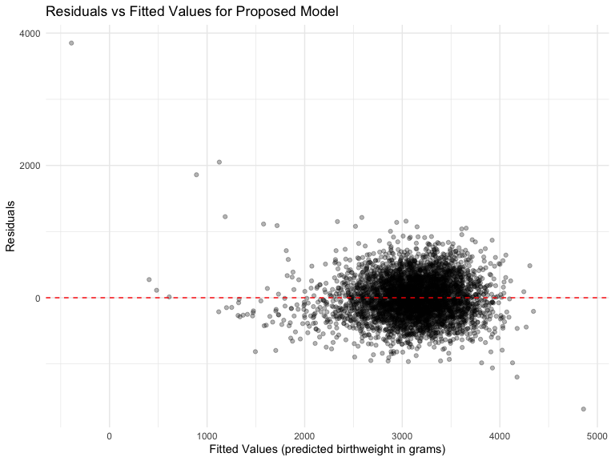

```r
birthweight_df |>
  add_predictions(proposed_model) |>
  add_residuals(proposed_model) |>
  ggplot(aes(x = pred, y = resid)) +
  geom_point(alpha = 0.3) +
  geom_hline(yintercept = 0, linetype = "dashed", color = "red") +
  labs(
    title = "Residuals vs Fitted Values for Proposed Model",
    x = "Fitted Values (predicted birthweight in grams)",
    y = "Residuals"
  )
```

### Model Comparison

Compare the proposed model with two alternatives using cross-validated prediction error. We use RMSE (Root Mean Squared Error) as the primary metric for comparison because:

- RMSE is in the same units as the outcome (grams), making it directly interpretable
- It penalizes larger prediction errors more heavily than smaller ones, which is appropriate when large errors are particularly undesirable
- Cross-validated RMSE estimates out-of-sample prediction accuracy, avoiding overfitting bias that can occur with in-sample metrics like R²

The three models compared are:

- **Model 1 (Proposed):** `bwt ~ blength + gaweeks + mrace + smoken + wtgain`
- **Model 2:** `bwt ~ blength + gaweeks` (main effects only)
- **Model 3:** `bwt ~ bhead * blength * babysex` (all interactions including three-way)

```r
# Define the three models
model_1 = \(df) lm(bwt ~ blength + gaweeks + mrace + smoken + wtgain, data = df)
model_2 = \(df) lm(bwt ~ blength + gaweeks, data = df)
model_3 = \(df) lm(bwt ~ bhead * blength * babysex, data = df)

# Cross-validation
set.seed(1)

cv_results =
  crossv_mc(birthweight_df, n = 100) |>
  mutate(
    train = map(train, as_tibble),
    test = map(test, as_tibble),
    model_proposed = map(train, model_1),
    model_length_ga = map(train, model_2),
    model_interactions = map(train, model_3),
    rmse_proposed = map2_dbl(model_proposed, test, \(mod, df) rmse(mod, df)),
    rmse_length_ga = map2_dbl(model_length_ga, test, \(mod, df) rmse(mod, df)),
    rmse_interactions = map2_dbl(model_interactions, test, \(mod, df) rmse(mod, df))
  )

# Summarize RMSE
cv_results |>
  select(starts_with("rmse")) |>
  pivot_longer(everything(), names_to = "model", values_to = "rmse", names_prefix = "rmse_") |>
  group_by(model) |>
  summarize(
    mean_rmse = mean(rmse),
    sd_rmse = sd(rmse)
  ) |>
  arrange(mean_rmse) |>
  knitr::kable(digits = 2)
```

| model | mean_rmse | sd_rmse |
| --- | --- | --- |
| interactions | 288.60 | 9.22 |
| proposed | 318.30 | 12.50 |
| length_ga | 332.23 | 13.95 |

### RMSE Distribution Plot

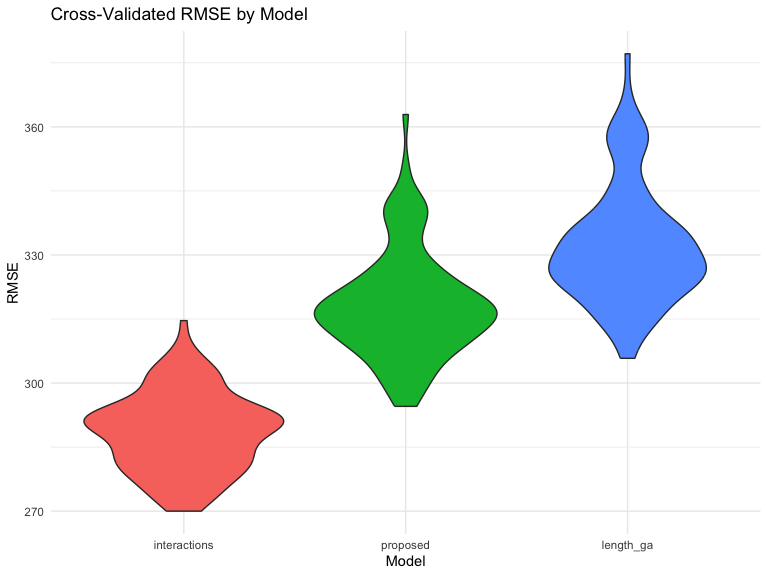

```r
cv_results |>
  select(starts_with("rmse")) |>
  pivot_longer(everything(), names_to = "model", values_to = "rmse", names_prefix = "rmse_") |>
  mutate(model = fct_reorder(model, rmse)) |>
  ggplot(aes(x = model, y = rmse, fill = model)) +
  geom_violin() +
  labs(
    title = "Cross-Validated RMSE by Model",
    x = "Model",
    y = "RMSE"
  ) +
  theme(legend.position = "none")
```

**Interpretation:** The cross-validated RMSE comparison shows that the interactions model (`bhead * blength * babysex`) has the lowest prediction error (mean RMSE ≈ 289), followed by the proposed model (mean RMSE ≈ 318), and the simple main effects model (mean RMSE ≈ 332).

The interactions model performs best because head circumference (`bhead`) is a strong predictor of birthweight, and allowing for interactions between head circumference, body length, and sex captures important relationships. The proposed model, while including relevant predictors like maternal race and smoking, does not include head circumference, which explains its higher RMSE. The simple model with only length and gestational age has the highest error due to omitting important predictors.